# Risk Factor Analysis

## Outcome Variable

**Outcome Variable:** pers_wasted624

## Predictor Variables

**Intervention Variable:** pers_wasted06

**Adjustment Set:**

- sex
- arm
- brthmon
- vagbrth
- single
- W_mage
- W_mhtcm
- W_mwtkg
- W_mbmi
- W_meducyrs
- W_feducyrs
- W_parity
- delta_brthmon
- delta_vagbrth
- delta_single
- delta_W_mage
- delta_W_mhtcm
- delta_W_mwtkg
- delta_W_mbmi
- delta_W_meducyrs
- delta_W_feducyrs
- delta_W_parity

## Stratifying Variables

The analysis was stratified on these variable(s):

- studyid
- country

## Data Summary

| studyid | country | pers_wasted06 | pers_wasted624 | n_cell | n | outcome_variable |
| --- | --- | --- | --- | --- | --- | --- |
| CMC-V-BCS-2002 | INDIA | 0 | 0 | 307 | 370 | pers_wasted624 |
| CMC-V-BCS-2002 | INDIA | 0 | 1 | 11 | 370 | pers_wasted624 |
| CMC-V-BCS-2002 | INDIA | 1 | 0 | 35 | 370 | pers_wasted624 |
| CMC-V-BCS-2002 | INDIA | 1 | 1 | 17 | 370 | pers_wasted624 |
| CMIN | BANGLADESH | 0 | 0 | 223 | 252 | pers_wasted624 |
| CMIN | BANGLADESH | 0 | 1 | 19 | 252 | pers_wasted624 |
| CMIN | BANGLADESH | 1 | 0 | 4 | 252 | pers_wasted624 |
| CMIN | BANGLADESH | 1 | 1 | 6 | 252 | pers_wasted624 |
| COHORTS | GUATEMALA | 0 | 0 | 934 | 1017 | pers_wasted624 |
| COHORTS | GUATEMALA | 0 | 1 | 31 | 1017 | pers_wasted624 |
| COHORTS | GUATEMALA | 1 | 0 | 42 | 1017 | pers_wasted624 |
| COHORTS | GUATEMALA | 1 | 1 | 10 | 1017 | pers_wasted624 |
| COHORTS | INDIA | 0 | 0 | 5684 | 6892 | pers_wasted624 |
| COHORTS | INDIA | 0 | 1 | 277 | 6892 | pers_wasted624 |
| COHORTS | INDIA | 1 | 0 | 438 | 6892 | pers_wasted624 |
| COHORTS | INDIA | 1 | 1 | 493 | 6892 | pers_wasted624 |
| COHORTS | PHILIPPINES | 0 | 0 | 2467 | 2808 | pers_wasted624 |
| COHORTS | PHILIPPINES | 0 | 1 | 161 | 2808 | pers_wasted624 |
| COHORTS | PHILIPPINES | 1 | 0 | 115 | 2808 | pers_wasted624 |
| COHORTS | PHILIPPINES | 1 | 1 | 65 | 2808 | pers_wasted624 |
| CONTENT | PERU | 0 | 0 | 215 | 215 | pers_wasted624 |
| CONTENT | PERU | 0 | 1 | 0 | 215 | pers_wasted624 |
| CONTENT | PERU | 1 | 0 | 0 | 215 | pers_wasted624 |
| CONTENT | PERU | 1 | 1 | 0 | 215 | pers_wasted624 |
| EE | PAKISTAN | 0 | 0 | 313 | 374 | pers_wasted624 |
| EE | PAKISTAN | 0 | 1 | 35 | 374 | pers_wasted624 |
| EE | PAKISTAN | 1 | 0 | 12 | 374 | pers_wasted624 |
| EE | PAKISTAN | 1 | 1 | 14 | 374 | pers_wasted624 |
| GMS-Nepal | NEPAL | 0 | 0 | 452 | 590 | pers_wasted624 |
| GMS-Nepal | NEPAL | 0 | 1 | 70 | 590 | pers_wasted624 |

[output cut: 90 more lines]

The following strata were considered:

- studyid: CMC-V-BCS-2002, country: INDIA
- studyid: CMIN, country: BANGLADESH
- studyid: COHORTS, country: GUATEMALA
- studyid: COHORTS, country: INDIA
- studyid: COHORTS, country: PHILIPPINES
- studyid: CONTENT, country: PERU
- studyid: EE, country: PAKISTAN
- studyid: GMS-Nepal, country: NEPAL
- studyid: Guatemala BSC, country: GUATEMALA
- studyid: IRC, country: INDIA
- studyid: JiVitA-3, country: BANGLADESH
- studyid: JiVitA-4, country: BANGLADESH
- studyid: Keneba, country: GAMBIA
- studyid: LCNI-5, country: MALAWI
- studyid: MAL-ED, country: BANGLADESH
- studyid: MAL-ED, country: BRAZIL
- studyid: MAL-ED, country: INDIA
- studyid: MAL-ED, country: NEPAL
- studyid: MAL-ED, country: PERU
- studyid: MAL-ED, country: SOUTH AFRICA
- studyid: MAL-ED, country: TANZANIA, UNITED REPUBLIC OF
- studyid: NIH-Birth, country: BANGLADESH
- studyid: NIH-Crypto, country: BANGLADESH
- studyid: PROBIT, country: BELARUS
- studyid: PROVIDE, country: BANGLADESH
- studyid: ResPak, country: PAKISTAN
- studyid: SAS-CompFeed, country: INDIA
- studyid: SAS-FoodSuppl, country: INDIA
- studyid: TanzaniaChild2, country: TANZANIA, UNITED REPUBLIC OF
- studyid: ZVITAMBO, country: ZIMBABWE

### Dropped Strata

Some strata were dropped due to rare outcomes:

- studyid: CMIN, country: BANGLADESH
- studyid: CONTENT, country: PERU
- studyid: Guatemala BSC, country: GUATEMALA
- studyid: MAL-ED, country: BANGLADESH
- studyid: MAL-ED, country: BRAZIL
- studyid: MAL-ED, country: NEPAL
- studyid: MAL-ED, country: PERU
- studyid: MAL-ED, country: SOUTH AFRICA
- studyid: MAL-ED, country: TANZANIA, UNITED REPUBLIC OF

## Methods Detail

We’re interested in the causal parameters $E[Y_a]$ for all values of $a \in \mathcal{A}$. These parameters represent the mean outcome if, possibly contrary to fact, we intervened to set all units to have $A=a$. Under the randomization and positivity assumptions, these are identified by the statistical parameters $\psi_a=E_W[E_{Y|A,W}(Y|A=a,W)]$. In addition, we’re interested in the mean of $Y$, $E[Y]$ under no intervention (the observed mean). We will estimate these parameters by using SuperLearner to fit the relevant likelihood factors – $E_{Y|A,W}(Y|A=a,W)$ and $p(A=a|W)$, and then updating our likelihood fit using a joint TMLE.

For unadjusted analyses ($W=\{\}$), initial likelihoods were estimated using Lrnr_glm to estimate the simple $E(Y|A)$ and Lrnr_mean to estimate $p(A)$. For adjusted analyses, a small library containing Lrnr_glmnet, Lrnr_xgboost, and Lrnr_mean was used.

Having estimated these parameters, we will then use the delta method to estimate relative risks and attributable risks relative to a prespecified baseline level of $A$.

# Results Detail

## Results Plots

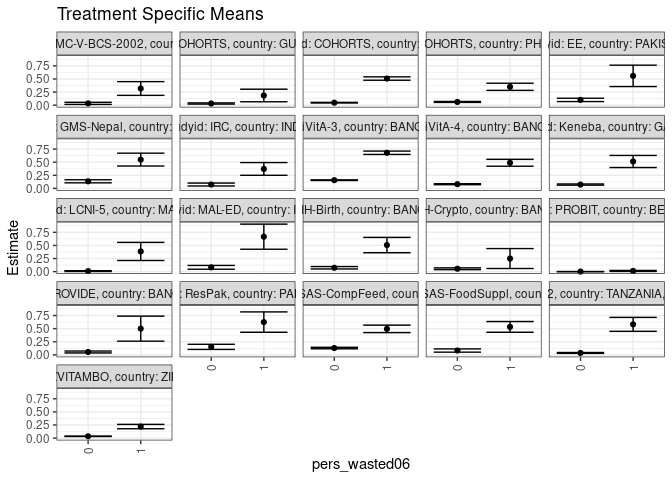

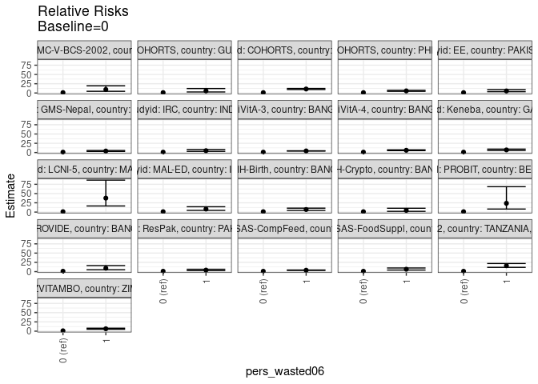

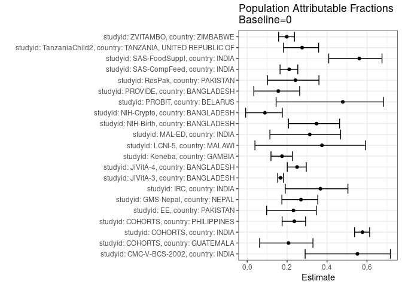

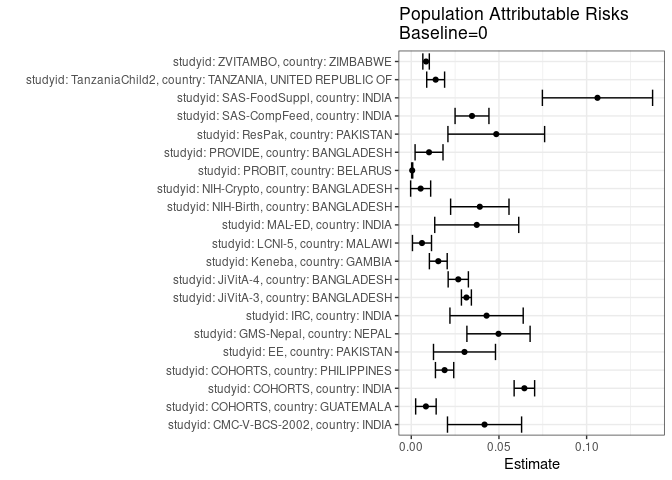

## Results Table

### Parameter: TSM

| studyid | country | intervention_level | baseline_level | estimate | ci_lower | ci_upper |
| --- | --- | --- | --- | --- | --- | --- |
| CMC-V-BCS-2002 | INDIA | 0 | NA | 0.0338929 | 0.0137740 | 0.0540118 |
| CMC-V-BCS-2002 | INDIA | 1 | NA | 0.3175894 | 0.1865932 | 0.4485856 |
| COHORTS | GUATEMALA | 0 | NA | 0.0319693 | 0.0208411 | 0.0430976 |
| COHORTS | GUATEMALA | 1 | NA | 0.1844546 | 0.0644755 | 0.3044337 |
| COHORTS | INDIA | 0 | NA | 0.0472184 | 0.0418199 | 0.0526169 |
| COHORTS | INDIA | 1 | NA | 0.5079059 | 0.4755748 | 0.5402371 |
| COHORTS | PHILIPPINES | 0 | NA | 0.0614864 | 0.0523189 | 0.0706539 |
| COHORTS | PHILIPPINES | 1 | NA | 0.3500782 | 0.2819469 | 0.4182095 |
| EE | PAKISTAN | 0 | NA | 0.1006674 | 0.0690253 | 0.1323095 |
| EE | PAKISTAN | 1 | NA | 0.5589175 | 0.3546964 | 0.7631386 |
| GMS-Nepal | NEPAL | 0 | NA | 0.1350014 | 0.1057153 | 0.1642875 |
| GMS-Nepal | NEPAL | 1 | NA | 0.5491667 | 0.4263158 | 0.6720175 |
| IRC | INDIA | 0 | NA | 0.0741330 | 0.0464941 | 0.1017720 |
| IRC | INDIA | 1 | NA | 0.3713685 | 0.2501304 | 0.4926065 |
| JiVitA-3 | BANGLADESH | 0 | NA | 0.1565663 | 0.1503960 | 0.1627367 |
| JiVitA-3 | BANGLADESH | 1 | NA | 0.6794257 | 0.6479290 | 0.7109223 |
| JiVitA-4 | BANGLADESH | 0 | NA | 0.0804700 | 0.0711113 | 0.0898287 |
| JiVitA-4 | BANGLADESH | 1 | NA | 0.4887073 | 0.4231407 | 0.5542739 |
| Keneba | GAMBIA | 0 | NA | 0.0729293 | 0.0620915 | 0.0837671 |
| Keneba | GAMBIA | 1 | NA | 0.5132802 | 0.3979815 | 0.6285788 |
| LCNI-5 | MALAWI | 0 | NA | 0.0102041 | 0.0031022 | 0.0173060 |
| LCNI-5 | MALAWI | 1 | NA | 0.3846154 | 0.2119598 | 0.5572710 |
| MAL-ED | INDIA | 0 | NA | 0.0818182 | 0.0455227 | 0.1181136 |
| MAL-ED | INDIA | 1 | NA | 0.6666667 | 0.4275982 | 0.9057351 |
| NIH-Birth | BANGLADESH | 0 | NA | 0.0734610 | 0.0504040 | 0.0965179 |
| NIH-Birth | BANGLADESH | 1 | NA | 0.5065339 | 0.3603030 | 0.6527648 |
| NIH-Crypto | BANGLADESH | 0 | NA | 0.0549296 | 0.0381589 | 0.0717003 |
| NIH-Crypto | BANGLADESH | 1 | NA | 0.2500000 | 0.0600972 | 0.4399028 |
| PROBIT | BELARUS | 0 | NA | 0.0005652 | 0.0000742 | 0.0010561 |
| PROBIT | BELARUS | 1 | NA | 0.0133929 | 0.0041540 | 0.0226317 |
| PROVIDE | BANGLADESH | 0 | NA | 0.0549085 | 0.0366394 | 0.0731775 |
| PROVIDE | BANGLADESH | 1 | NA | 0.5000000 | 0.2613176 | 0.7386824 |
| ResPak | PAKISTAN | 0 | NA | 0.1523810 | 0.1036692 | 0.2010927 |
| ResPak | PAKISTAN | 1 | NA | 0.6250000 | 0.4308989 | 0.8191011 |
| SAS-CompFeed | INDIA | 0 | NA | 0.1301061 | 0.1156442 | 0.1445679 |
| SAS-CompFeed | INDIA | 1 | NA | 0.4958557 | 0.4245532 | 0.5671581 |
| SAS-FoodSuppl | INDIA | 0 | NA | 0.0828536 | 0.0516652 | 0.1140419 |
| SAS-FoodSuppl | INDIA | 1 | NA | 0.5333702 | 0.4310985 | 0.6356418 |
| TanzaniaChild2 | TANZANIA, UNITED REPUBLIC OF | 0 | NA | 0.0366406 | 0.0283208 | 0.0449604 |
| TanzaniaChild2 | TANZANIA, UNITED REPUBLIC OF | 1 | NA | 0.5816670 | 0.4487289 | 0.7146052 |
| ZVITAMBO | ZIMBABWE | 0 | NA | 0.0341457 | 0.0306191 | 0.0376724 |
| ZVITAMBO | ZIMBABWE | 1 | NA | 0.2197318 | 0.1782000 | 0.2612636 |

### Parameter: E(Y)

| studyid | country | intervention_level | baseline_level | estimate | ci_lower | ci_upper |
| --- | --- | --- | --- | --- | --- | --- |
| CMC-V-BCS-2002 | INDIA | NA | NA | 0.0756757 | 0.0486905 | 0.1026609 |
| COHORTS | GUATEMALA | NA | NA | 0.0403147 | 0.0282199 | 0.0524094 |
| COHORTS | INDIA | NA | NA | 0.1117237 | 0.1042858 | 0.1191617 |
| COHORTS | PHILIPPINES | NA | NA | 0.0804843 | 0.0704205 | 0.0905481 |
| EE | PAKISTAN | NA | NA | 0.1310160 | 0.0967738 | 0.1652583 |
| GMS-Nepal | NEPAL | NA | NA | 0.1847458 | 0.1534039 | 0.2160876 |
| IRC | INDIA | NA | NA | 0.1170732 | 0.0859146 | 0.1482317 |
| JiVitA-3 | BANGLADESH | NA | NA | 0.1880070 | 0.1814627 | 0.1945512 |
| JiVitA-4 | BANGLADESH | NA | NA | 0.1072724 | 0.0967392 | 0.1178055 |
| Keneba | GAMBIA | NA | NA | 0.0883377 | 0.0767324 | 0.0999430 |
| LCNI-5 | MALAWI | NA | NA | 0.0163112 | 0.0075116 | 0.0251108 |
| MAL-ED | INDIA | NA | NA | 0.1191489 | 0.0776405 | 0.1606574 |
| NIH-Birth | BANGLADESH | NA | NA | 0.1125461 | 0.0859151 | 0.1391771 |
| NIH-Crypto | BANGLADESH | NA | NA | 0.0602740 | 0.0429977 | 0.0775502 |
| PROBIT | BELARUS | NA | NA | 0.0010846 | 0.0004977 | 0.0016715 |
| PROVIDE | BANGLADESH | NA | NA | 0.0650407 | 0.0455353 | 0.0845460 |
| ResPak | PAKISTAN | NA | NA | 0.2008547 | 0.1494120 | 0.2522974 |
| SAS-CompFeed | INDIA | NA | NA | 0.1647399 | 0.1451050 | 0.1843747 |
| SAS-FoodSuppl | INDIA | NA | NA | 0.1890547 | 0.1507312 | 0.2273783 |
| TanzaniaChild2 | TANZANIA, UNITED REPUBLIC OF | NA | NA | 0.0505451 | 0.0409848 | 0.0601054 |
| ZVITAMBO | ZIMBABWE | NA | NA | 0.0425869 | 0.0387663 | 0.0464075 |

### Parameter: RR

| studyid | country | intervention_level | baseline_level | estimate | ci_lower | ci_upper |
| --- | --- | --- | --- | --- | --- | --- |
| CMC-V-BCS-2002 | INDIA | 0 | 0 | 1.000000 | 1.000000 | 1.000000 |
| CMC-V-BCS-2002 | INDIA | 1 | 0 | 9.370382 | 4.535032 | 19.361290 |
| COHORTS | GUATEMALA | 0 | 0 | 1.000000 | 1.000000 | 1.000000 |
| COHORTS | GUATEMALA | 1 | 0 | 5.769733 | 2.771300 | 12.012350 |
| COHORTS | INDIA | 0 | 0 | 1.000000 | 1.000000 | 1.000000 |
| COHORTS | INDIA | 1 | 0 | 10.756522 | 9.441722 | 12.254414 |
| COHORTS | PHILIPPINES | 0 | 0 | 1.000000 | 1.000000 | 1.000000 |
| COHORTS | PHILIPPINES | 1 | 0 | 5.693587 | 4.459931 | 7.268483 |
| EE | PAKISTAN | 0 | 0 | 1.000000 | 1.000000 | 1.000000 |
| EE | PAKISTAN | 1 | 0 | 5.552121 | 3.424868 | 9.000652 |
| GMS-Nepal | NEPAL | 0 | 0 | 1.000000 | 1.000000 | 1.000000 |
| GMS-Nepal | NEPAL | 1 | 0 | 4.067860 | 2.975041 | 5.562102 |
| IRC | INDIA | 0 | 0 | 1.000000 | 1.000000 | 1.000000 |
| IRC | INDIA | 1 | 0 | 5.009487 | 3.047106 | 8.235668 |
| JiVitA-3 | BANGLADESH | 0 | 0 | 1.000000 | 1.000000 | 1.000000 |
| JiVitA-3 | BANGLADESH | 1 | 0 | 4.339538 | 4.093017 | 4.600907 |
| JiVitA-4 | BANGLADESH | 0 | 0 | 1.000000 | 1.000000 | 1.000000 |
| JiVitA-4 | BANGLADESH | 1 | 0 | 6.073162 | 5.095182 | 7.238857 |
| Keneba | GAMBIA | 0 | 0 | 1.000000 | 1.000000 | 1.000000 |
| Keneba | GAMBIA | 1 | 0 | 7.038049 | 5.375646 | 9.214545 |
| LCNI-5 | MALAWI | 0 | 0 | 1.000000 | 1.000000 | 1.000000 |
| LCNI-5 | MALAWI | 1 | 0 | 37.692308 | 16.465322 | 86.284983 |
| MAL-ED | INDIA | 0 | 0 | 1.000000 | 1.000000 | 1.000000 |
| MAL-ED | INDIA | 1 | 0 | 8.148148 | 4.606020 | 14.414249 |
| NIH-Birth | BANGLADESH | 0 | 0 | 1.000000 | 1.000000 | 1.000000 |
| NIH-Birth | BANGLADESH | 1 | 0 | 6.895280 | 4.498133 | 10.569915 |
| NIH-Crypto | BANGLADESH | 0 | 0 | 1.000000 | 1.000000 | 1.000000 |
| NIH-Crypto | BANGLADESH | 1 | 0 | 4.551282 | 2.007191 | 10.319981 |
| PROBIT | BELARUS | 0 | 0 | 1.000000 | 1.000000 | 1.000000 |
| PROBIT | BELARUS | 1 | 0 | 23.696429 | 8.189156 | 68.568818 |
| PROVIDE | BANGLADESH | 0 | 0 | 1.000000 | 1.000000 | 1.000000 |
| PROVIDE | BANGLADESH | 1 | 0 | 9.106061 | 5.088919 | 16.294295 |
| ResPak | PAKISTAN | 0 | 0 | 1.000000 | 1.000000 | 1.000000 |
| ResPak | PAKISTAN | 1 | 0 | 4.101562 | 2.626572 | 6.404857 |
| SAS-CompFeed | INDIA | 0 | 0 | 1.000000 | 1.000000 | 1.000000 |
| SAS-CompFeed | INDIA | 1 | 0 | 3.811165 | 3.318358 | 4.377158 |
| SAS-FoodSuppl | INDIA | 0 | 0 | 1.000000 | 1.000000 | 1.000000 |
| SAS-FoodSuppl | INDIA | 1 | 0 | 6.437503 | 4.212487 | 9.837762 |
| TanzaniaChild2 | TANZANIA, UNITED REPUBLIC OF | 0 | 0 | 1.000000 | 1.000000 | 1.000000 |
| TanzaniaChild2 | TANZANIA, UNITED REPUBLIC OF | 1 | 0 | 15.874943 | 11.501217 | 21.911927 |
| ZVITAMBO | ZIMBABWE | 0 | 0 | 1.000000 | 1.000000 | 1.000000 |
| ZVITAMBO | ZIMBABWE | 1 | 0 | 6.435114 | 5.189119 | 7.980294 |

### Parameter: PAR

| studyid | country | intervention_level | baseline_level | estimate | ci_lower | ci_upper |
| --- | --- | --- | --- | --- | --- | --- |
| CMC-V-BCS-2002 | INDIA | 0 | NA | 0.0417828 | 0.0206488 | 0.0629167 |
| COHORTS | GUATEMALA | 0 | NA | 0.0083453 | 0.0025009 | 0.0141897 |
| COHORTS | INDIA | 0 | NA | 0.0645053 | 0.0586612 | 0.0703494 |
| COHORTS | PHILIPPINES | 0 | NA | 0.0189979 | 0.0137841 | 0.0242117 |
| EE | PAKISTAN | 0 | NA | 0.0303487 | 0.0126718 | 0.0480255 |
| GMS-Nepal | NEPAL | 0 | NA | 0.0497444 | 0.0317214 | 0.0677674 |
| IRC | INDIA | 0 | NA | 0.0429401 | 0.0220495 | 0.0638308 |
| JiVitA-3 | BANGLADESH | 0 | NA | 0.0314406 | 0.0286021 | 0.0342791 |
| JiVitA-4 | BANGLADESH | 0 | NA | 0.0268024 | 0.0210350 | 0.0325698 |
| Keneba | GAMBIA | 0 | NA | 0.0154084 | 0.0103268 | 0.0204899 |
| LCNI-5 | MALAWI | 0 | NA | 0.0061071 | 0.0006741 | 0.0115401 |
| MAL-ED | INDIA | 0 | NA | 0.0373308 | 0.0133773 | 0.0612842 |
| NIH-Birth | BANGLADESH | 0 | NA | 0.0390852 | 0.0224407 | 0.0557296 |
| NIH-Crypto | BANGLADESH | 0 | NA | 0.0053444 | -0.0003673 | 0.0110561 |
| PROBIT | BELARUS | 0 | NA | 0.0005194 | 0.0002130 | 0.0008258 |
| PROVIDE | BANGLADESH | 0 | NA | 0.0101322 | 0.0021706 | 0.0180938 |
| ResPak | PAKISTAN | 0 | NA | 0.0484737 | 0.0209011 | 0.0760464 |
| SAS-CompFeed | INDIA | 0 | NA | 0.0346338 | 0.0249775 | 0.0442901 |
| SAS-FoodSuppl | INDIA | 0 | NA | 0.1062012 | 0.0747756 | 0.1376267 |
| TanzaniaChild2 | TANZANIA, UNITED REPUBLIC OF | 0 | NA | 0.0139045 | 0.0088047 | 0.0190043 |
| ZVITAMBO | ZIMBABWE | 0 | NA | 0.0084412 | 0.0065937 | 0.0102886 |

### Parameter: PAF

| studyid | country | intervention_level | baseline_level | estimate | ci_lower | ci_upper |
| --- | --- | --- | --- | --- | --- | --- |
| CMC-V-BCS-2002 | INDIA | 0 | NA | 0.5521296 | 0.2902829 | 0.7173692 |
| COHORTS | GUATEMALA | 0 | NA | 0.2070042 | 0.0623125 | 0.3293690 |
| COHORTS | INDIA | 0 | NA | 0.5773645 | 0.5379080 | 0.6134520 |
| COHORTS | PHILIPPINES | 0 | NA | 0.2360451 | 0.1750005 | 0.2925727 |
| EE | PAKISTAN | 0 | NA | 0.2316408 | 0.0972428 | 0.3460302 |
| GMS-Nepal | NEPAL | 0 | NA | 0.2692586 | 0.1737462 | 0.3537301 |
| IRC | INDIA | 0 | NA | 0.3667803 | 0.1906329 | 0.5045917 |
| JiVitA-3 | BANGLADESH | 0 | NA | 0.1672311 | 0.1529243 | 0.1812963 |
| JiVitA-4 | BANGLADESH | 0 | NA | 0.2498535 | 0.2007419 | 0.2959473 |
| Keneba | GAMBIA | 0 | NA | 0.1744257 | 0.1190581 | 0.2263134 |
| LCNI-5 | MALAWI | 0 | NA | 0.3744113 | 0.0387300 | 0.5928707 |
| MAL-ED | INDIA | 0 | NA | 0.3133117 | 0.1136573 | 0.4679927 |
| NIH-Birth | BANGLADESH | 0 | NA | 0.3472813 | 0.2069377 | 0.4627891 |
| NIH-Crypto | BANGLADESH | 0 | NA | 0.0886684 | -0.0078075 | 0.1759087 |
| PROBIT | BELARUS | 0 | NA | 0.4788998 | 0.1448179 | 0.6824706 |
| PROVIDE | BANGLADESH | 0 | NA | 0.1557820 | 0.0331417 | 0.2628662 |
| ResPak | PAKISTAN | 0 | NA | 0.2413374 | 0.1014563 | 0.3594424 |
| SAS-CompFeed | INDIA | 0 | NA | 0.2102333 | 0.1645188 | 0.2534465 |
| SAS-FoodSuppl | INDIA | 0 | NA | 0.5617482 | 0.4084472 | 0.6753212 |
| TanzaniaChild2 | TANZANIA, UNITED REPUBLIC OF | 0 | NA | 0.2750914 | 0.1818189 | 0.3577308 |
| ZVITAMBO | ZIMBABWE | 0 | NA | 0.1982101 | 0.1573392 | 0.2370986 |